# sperrorest-vignette: Spatial modeling using statistical learning techniques

Alexander Brenning, Patrick Schratz

2016-10-10

# Data and packages

```r
library(rpart)
library(MASS)
library(randomForest)
library(sperrorest)
```

The `maipo` data set from Marco Pena is used.

```r
data("maipo", package = "sperrorest")

data("ecuador", package = "sperrorest")
```

Variable description:

**Response**  
- `croptype`: response variable (factor) with 4 levels

**Predictors**  
- `b`[12-87]: spectral data, e.g. b82 = image date #8, spectral band #2  
- `ndvi`[01-08]: Normalized Differenced Vegetation Index, e.g. #8 = image date #8  
- `ndwi`[01-08]: Normalized Differenced Water Index, e.g. #8 = image date #8

**Others**  
- `field`: field identifier (grouping variable - not to be used as predictor)  
- `utmx`, `utm`y: x/y location; not to be used as predictors

# Preprocessing

Transform some of the predictor variables:

```r
predictors <- colnames(maipo)[5:ncol(maipo)]
# Construct a formula:
fo <- as.formula(paste("croptype ~", paste(predictors, collapse = "+")))
```

Take a quick look at (some) correlations among the predictors:

```r
co <- abs(cor(maipo[, predictors]) * 100)
co[co < 70] <- 0 # mask out weak/moderate correlations
head(round(co))
```

```
##     b12 b13 b14 b15 b16 b17 b22 b23 b24 b25 b26 b27 b32 b33 b34 b35 b36
## b12 100  97  98   0   0  84  81  81  79   0   0  70   0   0   0   0   0
## b13  97 100  96   0   0  75  79  83  78   0   0   0   0   0   0   0   0
## b14  98  96 100   0  72  87  80  82  82   0   0  75   0   0   0   0   0
## b15   0   0   0 100   0   0   0   0   0   0   0   0   0   0   0   0   0
## b16   0   0  72   0 100  94   0   0   0   0  89  82   0   0   0   0   0
## b17  84  75  87   0  94 100   0   0  72   0  83  86   0   0   0   0   0
##     b37 b42 b43 b44 b45 b46 b47 b52 b53 b54 b55 b56 b57 b62 b63 b64 b65
## b12   0   0   0   0   0   0   0   0   0   0   0   0   0   0   0   0   0
## b13   0   0   0   0   0   0   0   0   0   0   0   0   0   0   0   0   0
## b14   0   0   0   0   0   0   0   0   0   0   0   0   0   0   0   0   0
## b15   0   0   0   0   0   0   0   0   0   0   0   0   0   0   0   0   0
## b16   0   0   0   0   0   0   0   0   0   0   0   0   0   0   0   0   0
## b17   0   0   0   0   0   0   0   0   0   0   0   0   0   0   0   0   0
##     b66 b67 b72 b73 b74 b75 b76 b77 b82 b83 b84 b85 b86 b87 ndvi01 ndvi02
## b12   0   0   0   0   0   0   0   0   0   0   0   0   0   0     92     77
## b13   0   0   0   0   0   0   0   0   0   0   0   0   0   0     83     72
## b14   0   0   0   0   0   0   0   0   0   0   0   0   0   0     93     79
## b15   0   0   0   0   0   0   0   0   0   0   0   0   0   0     75      0
## b16   0   0   0   0   0   0   0   0   0   0   0   0   0   0      0      0
## b17   0   0   0   0   0   0   0   0   0   0   0   0   0   0     85     73
##     ndvi03 ndvi04 ndvi05 ndvi06 ndvi07 ndvi08 ndwi01 ndwi02 ndwi03 ndwi04
## b12      0      0      0      0      0      0     74      0      0      0
## b13      0      0      0      0      0      0      0      0      0      0
## b14      0      0      0      0      0      0     78      0      0      0
## b15      0      0      0      0      0      0     74      0      0      0
## b16      0      0      0      0      0      0     85     77      0      0
## b17      0      0      0      0      0      0     94     82      0      0
##     ndwi05 ndwi06 ndwi07 ndwi08
## b12      0      0      0      0
## b13      0      0      0      0
## b14      0      0      0      0
## b15      0      0      0      0
## b16      0      0      0      0
## b17      0      0      0      0
```

# Modeling

## Linear discriminant analysis (LDA)

Fit a model with all predictors:

```r
fit <- MASS::lda(fo, data = maipo)
```

Predict the croptype with the fitted model and calculate the average misclassification error rate (MER):

```r
pred <- predict(fit, newdata = maipo)$class
mean(pred != maipo$croptype)
```

```
## [1] 0.04369247
```

Take a look at the confusion matrix:

```r
table(pred = pred, obs = maipo$croptype)
```

```
##        obs
## pred    crop1 crop2 crop3 crop4
##   crop1  1294     8     4    37
##   crop2    50  1054     4    44
##   crop3     0     0  1935     6
##   crop4    45   110    29  3093
```

## Classification Tree

Fit a model with all predictors:

```r
fit <- rpart(fo, data = maipo)
#            control = rpart.control(cp=0.01))

## optional: view the classiciation tree
# par(xpd = TRUE)
# plot(fit)
# text(fit, use.n = TRUE)
```

Again, predict the croptype with the fitted model and calculate the average MER:

```r
pred <- predict(fit, newdata = maipo, type = "class")
mean(pred != maipo$croptype)
```

```
## [1] 0.1127966
```

And take a look at the confusion matrix:

```r
table(pred = pred, obs = maipo$croptype)
```

```
##        obs
## pred    crop1 crop2 crop3 crop4
##   crop1  1204    66     0    54
##   crop2    47   871    38   123
##   crop3    38     8  1818    53
##   crop4   100   227   116  2950
```

Note that some classes may be over-/underpredicted, i.e. remotely-sensed crop areas can be biased even if accuracy is high!:

```r
summary(pred)
## crop1 crop2 crop3 crop4
##  1324  1079  1917  3393
summary(maipo$croptype)
## crop1 crop2 crop3 crop4
##  1389  1172  1972  3180
```

## Random Forest

(This will take some time…)

```r
fit <- randomForest(fo, data = maipo, importance = TRUE)
fit
```

```
##
## Call:
##  randomForest(formula = fo, data = maipo, importance = TRUE)
##                Type of random forest: classification
##                      Number of trees: 500
## No. of variables tried at each split: 8
##
##         OOB estimate of  error rate: 0.56%
## Confusion matrix:
##       crop1 crop2 crop3 crop4 class.error
## crop1  1382     2     0     5 0.005039597
## crop2     1  1162     0     9 0.008532423
## crop3     0     0  1961    11 0.005578093
## crop4     5     7     3  3165 0.004716981
```

Variable importance plot:

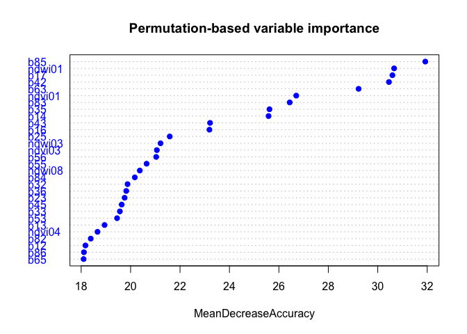

```r
varImpPlot(fit, type = 1, pch = 19, col = "blue",
           main = "Permutation-based variable importance")
```

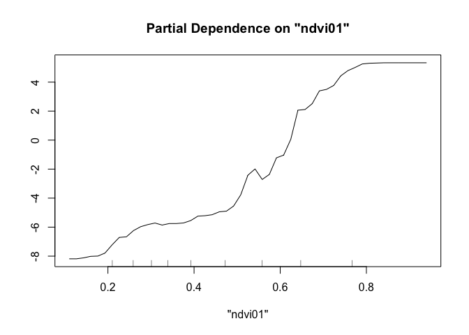

```r
partialPlot(fit, maipo, x.var = "ndvi01", which.class = "crop1")
```

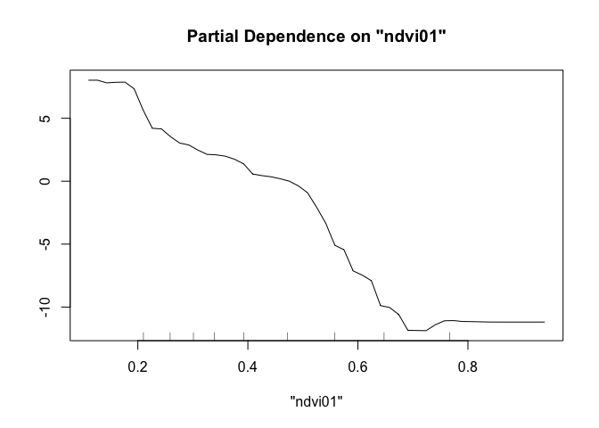

```r
partialPlot(fit, maipo, x.var = "ndvi01", which.class = "crop3")
```

Training-set misclassification error rate (MER)

```r
pred <- predict(fit, newdata = maipo, type = "class")
mean(pred != maipo$croptype)
```

```
## [1] 0
```

Confusion matrix:

```r
table(pred = pred, obs = maipo$croptype)
```

```
##        obs
## pred    crop1 crop2 crop3 crop4
##   crop1  1389     0     0     0
##   crop2     0  1172     0     0
##   crop3     0     0  1972     0
##   crop4     0     0     0  3180
```

- No misclassification at all!
- Even RF’s OOB (out-of-bag) estimate of the error rate is <1%.
- Too good to be true? We’ll see…

# Cross-validation estimation of predictive performance

# LDA

We need to set up some functions to create a wrapper predict function of the LDA model for `sperrorest`.

```r
library(nnet)
majority <- function(x) {
  levels(x)[which.is.max(table(x))]
}
```

```r
majority.filter <- function(x, fac) {
  for (lev in levels(fac)) {
    x[ fac == lev ] <- majority(x[ fac == lev ])
  }
  x
}
```

```r
lda.predfun <- function(object, newdata, fac = NULL) {
  pred <- predict(object, newdata = newdata)$class
  if (!is.null(fac)) pred <- majority.filter(pred, newdata[,fac])
  return(pred)
}
```

Finally, we can run `sperrorest` with a non-spatial sampling setup (`partition.cv`):

```r
res.lda.nsp <- res <- sperrorest(fo, data = maipo, coords = c("utmx","utmy"),
                                 model.fun = lda,
                                 pred.fun = lda.predfun,
                                 pred.args = list(fac = "field"),
                                 smp.fun = partition.cv,
                                 smp.args = list(repetition = 1:4, nfold = 5),
                                 err.rep = TRUE, err.fold = FALSE)
## Mon Oct 10 13:19:46 2016 Repetition 1
## Mon Oct 10 13:19:46 2016 - Fold 1
## Mon Oct 10 13:19:49 2016 - Fold 2
## Mon Oct 10 13:19:51 2016 - Fold 3
## Mon Oct 10 13:19:52 2016 - Fold 4
## Mon Oct 10 13:19:54 2016 - Fold 5
## Mon Oct 10 13:19:56 2016 Repetition 2
## Mon Oct 10 13:19:56 2016 - Fold 1
## Mon Oct 10 13:19:58 2016 - Fold 2
## Mon Oct 10 13:19:59 2016 - Fold 3
## Mon Oct 10 13:20:01 2016 - Fold 4
## Mon Oct 10 13:20:03 2016 - Fold 5
## Mon Oct 10 13:20:05 2016 Repetition 3
## Mon Oct 10 13:20:05 2016 - Fold 1
## Mon Oct 10 13:20:06 2016 - Fold 2
## Mon Oct 10 13:20:08 2016 - Fold 3
## Mon Oct 10 13:20:10 2016 - Fold 4
## Mon Oct 10 13:20:12 2016 - Fold 5
## Mon Oct 10 13:20:14 2016 Repetition 4
## Mon Oct 10 13:20:14 2016 - Fold 1
## Mon Oct 10 13:20:16 2016 - Fold 2
## Mon Oct 10 13:20:19 2016 - Fold 3
## Mon Oct 10 13:20:22 2016 - Fold 4
## Mon Oct 10 13:20:24 2016 - Fold 5
## Mon Oct 10 13:20:26 2016 Done.
round(summary(res.lda.nsp$err.rep), 3)
```

```
##                     mean    sd    median   IQR
## train.error        0.034 0.001     0.034 0.001
## train.accuracy     0.966 0.001     0.966 0.001
## train.events    4688.000 0.000  4688.000 0.000
## train.count    30852.000 0.000 30852.000 0.000
## test.error         0.039 0.001     0.039 0.001
## test.accuracy      0.961 0.001     0.961 0.001
## test.events     1172.000 0.000  1172.000 0.000
## test.count      7713.000 0.000  7713.000 0.000
```

To run a spatial cross-validation at the field level, we can use `partition.factor.cv` as the sampling function. Subsequently, we have to specify the location of the fields. We can do so using the `field` variable of our data set and put in `smp.args`:

```r
res.lda.sp <- sperrorest(fo, data = maipo, coords = c("utmx","utmy"),
                         model.fun = lda,
                         pred.fun = lda.predfun,
                         pred.args = list(fac = "field"),
                         smp.fun = partition.factor.cv,
                         smp.args = list(fac = "field", repetition = 1:4, nfold = 5),
                         err.rep = TRUE, err.fold = FALSE)
## Mon Oct 10 13:20:26 2016 Repetition 1
## Mon Oct 10 13:20:26 2016 - Fold 1
## Mon Oct 10 13:20:30 2016 - Fold 2
## Mon Oct 10 13:20:32 2016 - Fold 3
## Mon Oct 10 13:20:34 2016 - Fold 4
## Mon Oct 10 13:20:36 2016 - Fold 5
## Mon Oct 10 13:20:38 2016 Repetition 2
## Mon Oct 10 13:20:38 2016 - Fold 1
## Mon Oct 10 13:20:39 2016 - Fold 2
## Mon Oct 10 13:20:41 2016 - Fold 3
## Mon Oct 10 13:20:43 2016 - Fold 4
## Mon Oct 10 13:20:45 2016 - Fold 5
## Mon Oct 10 13:20:47 2016 Repetition 3
## Mon Oct 10 13:20:47 2016 - Fold 1
## Mon Oct 10 13:20:48 2016 - Fold 2
## Mon Oct 10 13:20:50 2016 - Fold 3
## Mon Oct 10 13:20:53 2016 - Fold 4
## Mon Oct 10 13:20:54 2016 - Fold 5
## Mon Oct 10 13:20:56 2016 Repetition 4
## Mon Oct 10 13:20:56 2016 - Fold 1
## Mon Oct 10 13:20:58 2016 - Fold 2
## Mon Oct 10 13:21:00 2016 - Fold 3
## Mon Oct 10 13:21:02 2016 - Fold 4
## Mon Oct 10 13:21:04 2016 - Fold 5
## Mon Oct 10 13:21:06 2016 Done.
round(summary(res.lda.sp$err.rep), 3)
```

```
##                     mean    sd    median   IQR
## train.error        0.028 0.001     0.028 0.001
## train.accuracy     0.972 0.001     0.972 0.001
## train.events    4688.000 0.000  4688.000 0.000
## train.count    30852.000 0.000 30852.000 0.000
## test.error         0.065 0.009     0.062 0.006
## test.accuracy      0.935 0.009     0.938 0.006
## test.events     1172.000 0.000  1172.000 0.000
## test.count      7713.000 0.000  7713.000 0.000
```

# RF

Setup prediction function for random forest:

```r
rf.predfun <- function(object, newdata, fac = NULL) {
  pred <- predict(object, newdata = newdata)
  if (!is.null(fac)) pred <- majority.filter(pred, newdata[,fac])
  return(pred)
}
```

Perform spatial cross-validation at the field level. Executing every repetition sequentially takes quite some time. we can take the parallelized versions of `sperrorest`, `parsperrorest` or `sperrorest.par`.

The advantage of `sperrorest.par` is that you can the progress of your current run. For Unix-Systems, the progress is directly reported to the console. For Windows, it is written to a textfile named “sperrorest.txt” in your current working directory.

```r
res.rf.sp <- sperrorest(fo, data = maipo, coords = c("utmx","utmy"),
                        model.fun = randomForest,
                        pred.fun = rf.predfun,
                        pred.args = list(fac = "field"),
                        smp.fun = partition.factor.cv,
                        smp.args = list(fac = "field",
                                        repetition = 1:4, nfold = 5),
                        err.rep = TRUE, err.fold = FALSE,
                        benchmark = TRUE, silent = FALSE)
## Mon Oct 10 13:21:06 2016 Repetition 1
## Mon Oct 10 13:21:06 2016 - Fold 1
## Mon Oct 10 13:21:28 2016 - Fold 2
## Mon Oct 10 13:21:45 2016 - Fold 3
## Mon Oct 10 13:22:03 2016 - Fold 4
## Mon Oct 10 13:22:19 2016 - Fold 5
## Mon Oct 10 13:22:35 2016 Repetition 2
## Mon Oct 10 13:22:35 2016 - Fold 1
## Mon Oct 10 13:22:53 2016 - Fold 2
## Mon Oct 10 13:23:11 2016 - Fold 3
## Mon Oct 10 13:23:30 2016 - Fold 4
## Mon Oct 10 13:23:51 2016 - Fold 5
## Mon Oct 10 13:24:13 2016 Repetition 3
## Mon Oct 10 13:24:13 2016 - Fold 1
## Mon Oct 10 13:24:35 2016 - Fold 2
## Mon Oct 10 13:24:55 2016 - Fold 3
## Mon Oct 10 13:25:12 2016 - Fold 4
## Mon Oct 10 13:25:36 2016 - Fold 5
## Mon Oct 10 13:26:00 2016 Repetition 4
## Mon Oct 10 13:26:00 2016 - Fold 1
## Mon Oct 10 13:26:23 2016 - Fold 2
## Mon Oct 10 13:26:44 2016 - Fold 3
## Mon Oct 10 13:27:02 2016 - Fold 4
## Mon Oct 10 13:27:23 2016 - Fold 5
## Mon Oct 10 13:27:42 2016 Done.
res.rf.sp$benchmark
```

```
## $system.info
##                                                                                           sysname
##                                                                                          "Darwin"
##                                                                                           release
##                                                                                          "16.0.0"
##                                                                                           version
## "Darwin Kernel Version 16.0.0: Mon Aug 29 17:56:20 PDT 2016; root:xnu-3789.1.32~3/RELEASE_X86_64"
##                                                                                          nodename
##                                                                                        "pamacpro"
##                                                                                           machine
##                                                                                          "x86_64"
##                                                                                             login
##                                                                                             "pjs"
##                                                                                              user
##                                                                                             "pjs"
##                                                                                    effective_user
##                                                                                             "pjs"
##
## $t.start
## [1] "2016-10-10 13:21:06 CEST"
##
## $t.end
## [1] "2016-10-10 13:27:42 CEST"
##
## $cpu.cores
## [1] 4
##
## $par.mode
## [1] NA
##
## $par.units
## [1] NA
##
## $runtime.performance
## Time difference of 6.597414 mins
##
## attr(,"class")
## [1] "sperrorestbenchmarks"
```

Läuft mit par.mode = 1

```r
res.rf.sp.par <- parsperrorest(fo, data = maipo, coords = c("utmx","utmy"),
                               model.fun = randomForest,
                               pred.fun = rf.predfun,
                               pred.args = list(fac = "field"),
                               smp.fun = partition.factor.cv,
                               smp.args = list(fac = "field",
                                               repetition = 1:4, nfold = 5),
                               par.args = list(par.mode = 1, par.units = 2,
                                               lb = T, high = TRUE),
                               err.rep = TRUE, err.fold = FALSE,
                               benchmark = TRUE, silent = FALSE)
```

```
## [1] "This is the parallel sperrorest code."
## Mon Oct 10 13:31:10 2016 Done.
```

```r
res.rf.sp.par$benchmark
```

```
## $system.info
##                                                                                           sysname
##                                                                                          "Darwin"
##                                                                                           release
##                                                                                          "16.0.0"
##                                                                                           version
## "Darwin Kernel Version 16.0.0: Mon Aug 29 17:56:20 PDT 2016; root:xnu-3789.1.32~3/RELEASE_X86_64"
##                                                                                          nodename
##                                                                                        "pamacpro"
##                                                                                           machine
##                                                                                          "x86_64"
##                                                                                             login
##                                                                                             "pjs"
##                                                                                              user
##                                                                                             "pjs"
##                                                                                    effective_user
##                                                                                             "pjs"
##
## $t.start
## [1] "2016-10-10 13:27:42 CEST"
##
## $t.end
## [1] "2016-10-10 13:31:10 CEST"
##
## $cpu.cores
## [1] 4
##
## $par.mode
## [1] 1
##
## $par.units
## [1] 2
##
## $runtime.performance
## Time difference of 3.45614 mins
##
## attr(,"class")
## [1] "sperrorestbenchmarks"
```

Läuft nicht (accumulate errors in foreach .combine)

```r
res.rf.sp.par1 <- sperrorest.par(fo, data = maipo, coords = c("utmx","utmy"),
                                 model.fun = randomForest,
                                 pred.fun = rf.predfun,
                                 pred.args = list(fac = "field"),
                                 smp.fun = partition.factor.cv,
                                 smp.args = list(fac = "field",
                                                 repetition = 1:4, nfold = 5),
                                 par.units = 2, silent = 2,
                                 err.fold = T, err.rep = T,
                                 benchmark = TRUE)
res.rf.sp.par1$benchmark
```